# ME - GIA. Introduccio MLGz (Factors i covariables. Interacció)

2024-10-02

## Introducció

Es vol comparar les valoracions (**V** o **VV**) de dos mètodes pedagògics (**M**) en funció del coeficient d’intel·ligència (**C**) amb les dades del fitxer `comrect.csv`. Plantegeu i ajusteu un model lineal generalitzat de les valoracions *V* o *VV* en funció del factor M i de la covariable C. Valoreu incloure els termes d’interacció i contesteu les preguntes següents:

1. Les dues rectes són iguals? o no?
2. Les dues rectes són paral·leles? o no?
3. Les dues rectes tenen el mateix terme independent? o no?
4. Per cadascun dels valors 90, 105 i 120 de la variable *C*, quines diferències hi ha en la valoració segons el mètode?

```r
# Carregar llibreries
library(emmeans)
library(car)

# Llegir dades
dd   <- read.csv2("../Dades/comrect.csv")
dd$M <- factor(dd$M)
```

### Descriptiva

Amb la resposta *V*, sembla que **NO** hi ha interacció:

- L’efecte del mètode pedagògic **NO** depen del coeficient intelectual.

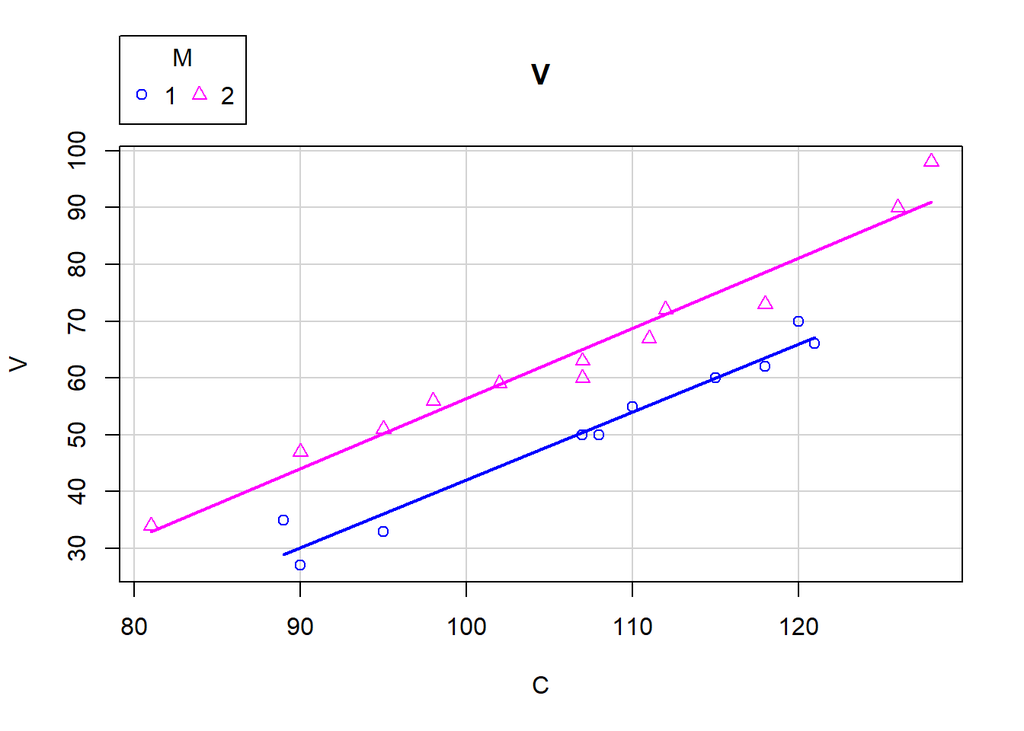

```r
scatterplot(V  ~ C|M, smooth = F, data = dd, main="V")
```

Amb la resposta *VV*, sembla que **SÍ** que hi ha interacció:

- L’efecte del mètode pedagògic **SÍ** depen del coeficient intelectual.

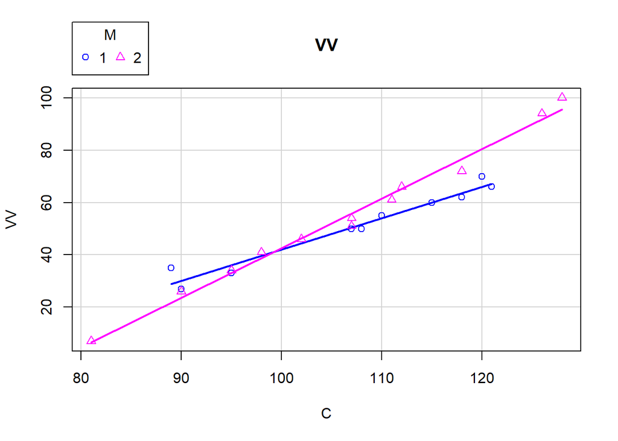

```r
scatterplot(VV ~ C|M, smooth = F, data = dd, main="VV")
```

## Models amb *V* com resposta

### Família normal amb link canònic (*identity*). Sense interacció

#### Model

- El Model sense interacció s’anomena **additiu** (*mvg*)
- El model **nul** és aquell que no té cap variable explicativa (*mvg0*)

```r
# No fa falta link="identity" per ser link canònic veure ?family
mvg  <- glm(V ~ M + C, family=gaussian, dd)
mvg0 <- glm(V ~ 1,     family=gaussian, dd)
```

Resum del model

```r
summary(mvg)
```

```
##
## Call:
## glm(formula = V ~ M + C, family = gaussian, data = dd)
##
## Coefficients:
##              Estimate Std. Error t value Pr(>|t|)
## (Intercept) -80.11563    6.25264  -12.81 8.50e-11 ***
## M2           14.64776    1.45307   10.08 4.62e-09 ***
## C             1.22009    0.05741   21.25 1.05e-14 ***
## ---
## Signif. codes:  0 '***' 0.001 '**' 0.01 '*' 0.05 '.' 0.1 ' ' 1
##
## (Dispersion parameter for gaussian family taken to be 11.49699)
##
##     Null deviance: 6385.82  on 21  degrees of freedom
## Residual deviance:  218.44  on 19  degrees of freedom
## AIC: 120.93
##
## Number of Fisher Scoring iterations: 2
```

- Per cada increment unitari del coeficient intelectual (*C*), la valoració *V* s’incrementa en **1.22 unitats**.
- El mètode pedagògic 2 (*M2*), incrementa la valoració *V* en **14.6 unitats**.

Resum gràfic del model (`emmip`del paquet `emmeans`). El resum gràfic del model s’assembla molt al de les dades.

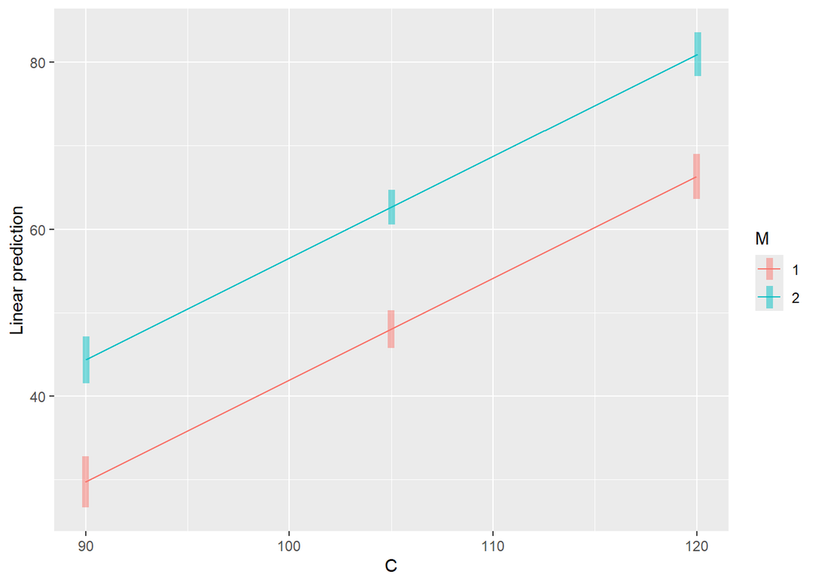

```r
emmip(mvg, M~C, CIs = T, at = list(C = c(90,105,120)))
```

**Test omnibus**. El test omnibus és aquell que compara el nostre model amb el model nul mitjançant un test de deviànces.

```r
anova(mvg0, mvg, test = "F")
```

```
## Analysis of Deviance Table
##
## Model 1: V ~ 1
## Model 2: V ~ M + C
##   Resid. Df Resid. Dev Df Deviance      F    Pr(>F)
## 1        21     6385.8
## 2        19      218.4  2   6167.4 268.22 1.186e-14 ***
## ---
## Signif. codes:  0 '***' 0.001 '**' 0.01 '*' 0.05 '.' 0.1 ' ' 1
```

#### Interpretació

Emprarem la funció `emmeans` per fer les estimacions als valors de C: 90, 105 i 120 (també podriem fer servir *predict*)

```r
emmeans(mvg, ~M|C, at=list(C = c(90,105,120)))
```

```
## C =  90:
##  M emmean    SE df lower.CL upper.CL
##  1   29.7 1.462 19     26.6     32.8
##  2   44.3 1.352 19     41.5     47.2
##
## C = 105:
##  M emmean    SE df lower.CL upper.CL
##  1   48.0 1.080 19     45.7     50.3
##  2   62.6 0.981 19     60.6     64.7
##
## C = 120:
##  M emmean    SE df lower.CL upper.CL
##  1   66.3 1.297 19     63.6     69.0
##  2   80.9 1.257 19     78.3     83.6
##
## Confidence level used: 0.95
```

Emprarem la funció `emtrends` per fer les estimacions dels pendents de les dues rectes

```r
emtrends(mvg, ~M, var="C")
```

```
##  M C.trend     SE df lower.CL upper.CL
##  1    1.22 0.0574 19      1.1     1.34
##  2    1.22 0.0574 19      1.1     1.34
##
## Confidence level used: 0.95
```

#### Validació

La **Linealitat** i la **Homoscedasticitat** semblen comportar-se prou bé.

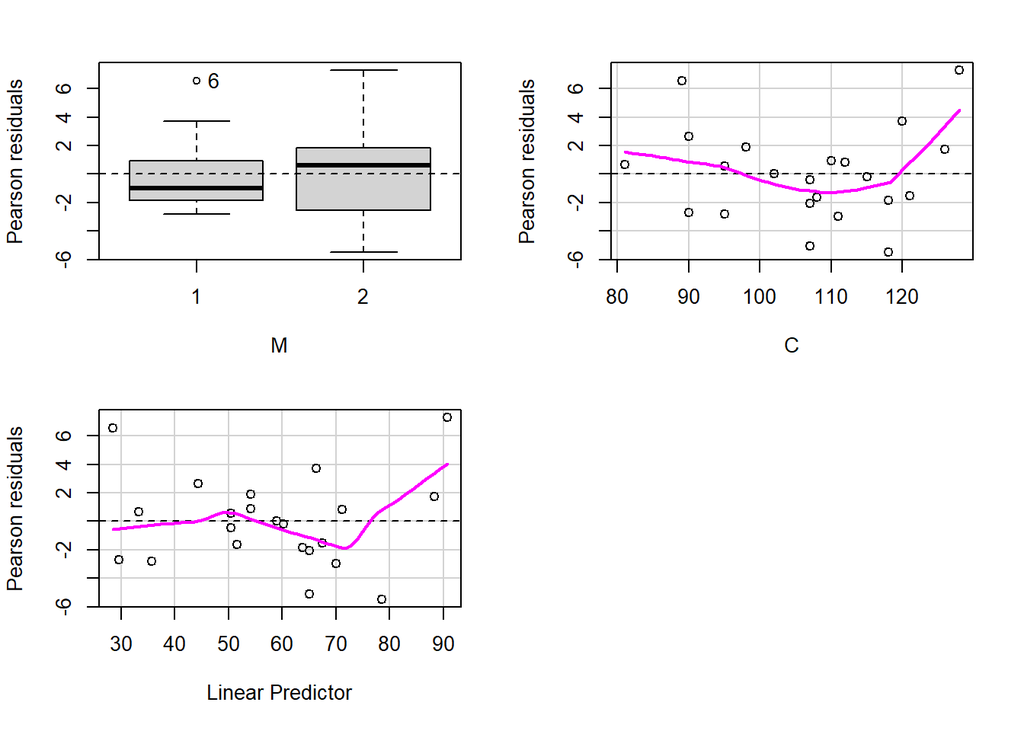

```
##   Test stat Pr(>|Test stat|)
## M
## C    53.172        3.055e-13 ***
## ---
## Signif. codes:  0 '***' 0.001 '**' 0.01 '*' 0.05 '.' 0.1 ' ' 1
```

```r
residualPlots(mvg)
```

**Valors estranys i influents**

El individu **21** és el que té més influència sobre el model (major distància de Cook) i també el pitjor explicat (residu més gran).

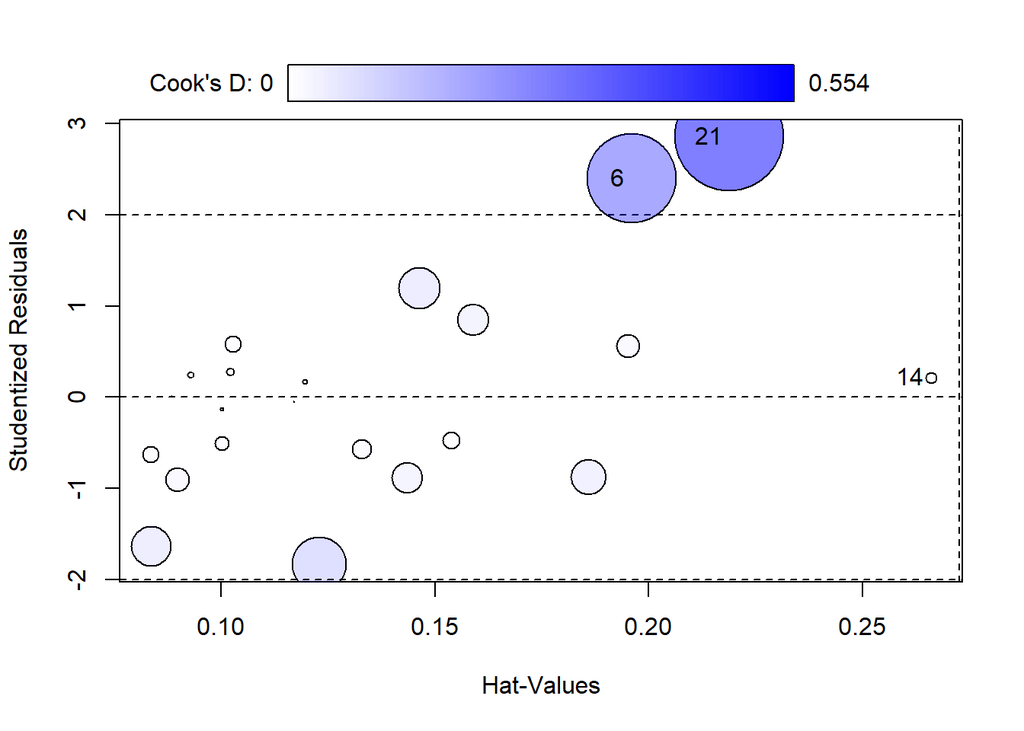

```
##      StudRes       Hat       CookD
## 6  2.4012558 0.1960024 0.374592625
## 14 0.2149277 0.2661024 0.005878208
## 21 2.8572579 0.2189454 0.553965757
```

```r
influencePlot(model = mvg)
```

#### Predicció

Calcularem els intervals de predicció per les dues rectes.

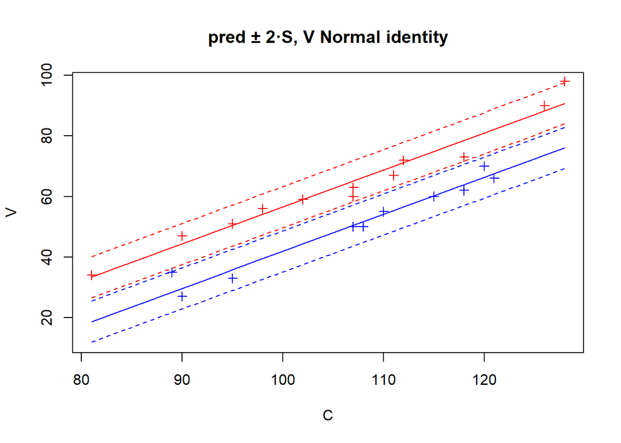

```r
CS <- min(dd$C):max(dd$C)

P1 <- predict(mvg, data.frame(C=CS, M="1"), type = "response") # Point estimates M=1
P2 <- predict(mvg, data.frame(C=CS, M="2"), type = "response") # Point estimates M=2

disp      <- summary(mvg)$dispersion  # parametre de dispersio
var_func1 <- family(mvg)$variance(P1) # funcio de variancia M=1
var_func2 <- family(mvg)$variance(P2) # funcio de variancia M=2

IP1 <- cbind(P1 - 2 * sqrt(disp * var_func1),
             P1 + 2 * sqrt(disp * var_func1))
IP2 <- cbind(P2 - 2 * sqrt(disp * var_func2),
             P2 + 2 * sqrt(disp * var_func2))

dd1 <- subset(dd, M=="1")
dd2 <- subset(dd, M=="2")

# Punts pels 2 metodes pedagogics
plot  (V ~ C, dd1, pch=3, col="blue", xlim = range(CS), ylim = range(c(IP1,IP2)),
       main="pred ± 2·S, V Normal identity")
points(V ~ C, dd2, pch=3, col="red")

# IP metode 1
lines(CS, P1,      col="blue")
lines(CS, IP1[,1], col="blue", lty=2)
lines(CS, IP1[,2], col="blue", lty=2)

# IP metode 2
lines(CS, P2,      col="red")
lines(CS, IP2[,1], col="red", lty=2)
lines(CS, IP2[,2], col="red", lty=2)
```

### Família normal amb link *inverse*. Sense interacció

Veurem que canviant el link, el model no ajusta bé.

```r
mvgl  <- glm(V ~ M + C, dd, family = gaussian(link=inverse))
```

#### Validació

**Linealitat i Homoscedasticitat**

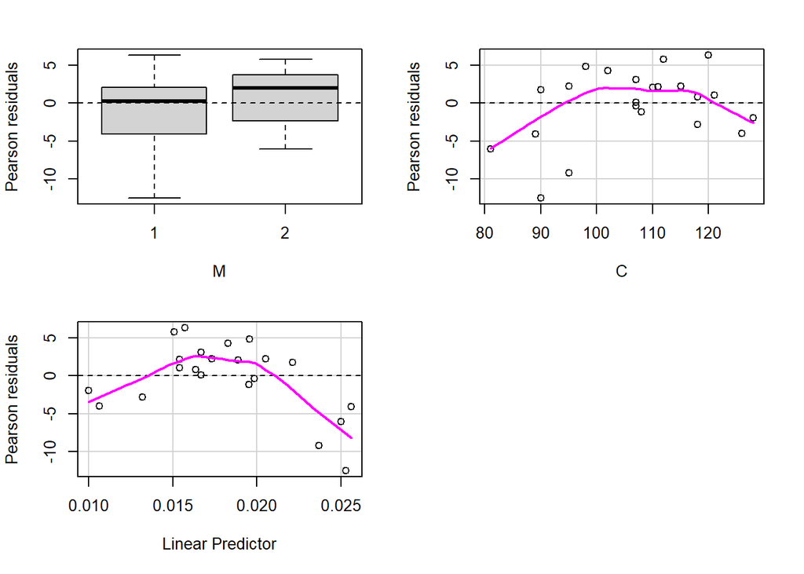

```
##   Test stat Pr(>|Test stat|)
## M
## C    135.63        < 2.2e-16 ***
## ---
## Signif. codes:  0 '***' 0.001 '**' 0.01 '*' 0.05 '.' 0.1 ' ' 1
```

```r
residualPlots(mvgl)
```

#### Predicció

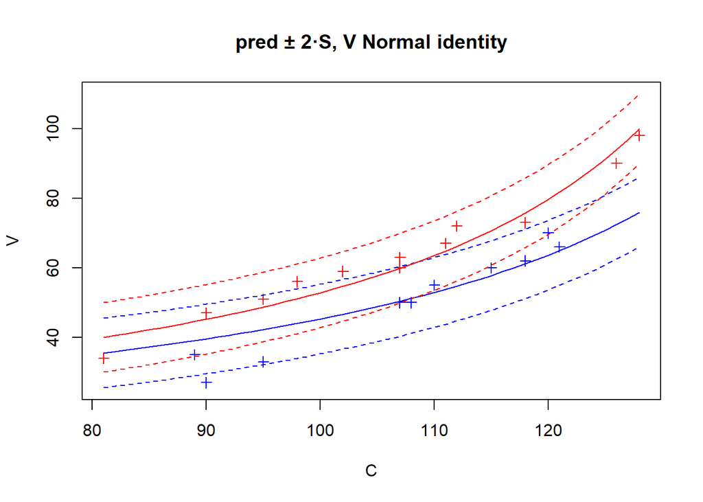

```r
CS <- min(dd$C):max(dd$C)

P1 <- predict(mvgl, data.frame(C=CS, M="1"), type = "response")        # Point estimates M=1
P2 <- predict(mvgl, data.frame(C=CS, M="2"), type = "response")        # Point estimates M=2

disp      <- summary(mvgl)$dispersion  # parametre de dispersio
var_func1 <- family(mvgl)$variance(P1) # funcio de variancia M=1
var_func2 <- family(mvgl)$variance(P2) # funcio de variancia M=2

IP1 <- cbind(P1 - 2 * sqrt(disp * var_func1),
             P1 + 2 * sqrt(disp * var_func1))
IP2 <- cbind(P2 - 2 * sqrt(disp * var_func2),
             P2 + 2 * sqrt(disp * var_func2))

# Punts pels 2 metodes
plot  (V ~ C, dd1, pch=3, col="blue", xlim = range(CS), ylim = range(c(IP1,IP2)),
       main="pred ± 2·S, V Normal identity")
points(V ~ C, dd2, pch=3, col="red")

# IP metode 1
lines(CS, P1,      col="blue")
lines(CS, IP1[,1], col="blue", lty=2)
lines(CS, IP1[,2], col="blue", lty=2)

# IP metode 2
lines(CS, P2,      col="red")
lines(CS, IP2[,1], col="red", lty=2)
lines(CS, IP2[,2], col="red", lty=2)
```

### Família Gamma amb link *identity*. Sense interacció

Veurem que canviant la família no es compleix la homoscedasticitat.

```r
mvgg  <- glm(V~M+C,family = Gamma(link = identity), dd)
```

#### Validació

**Linealitat i Homoscedasticitat**

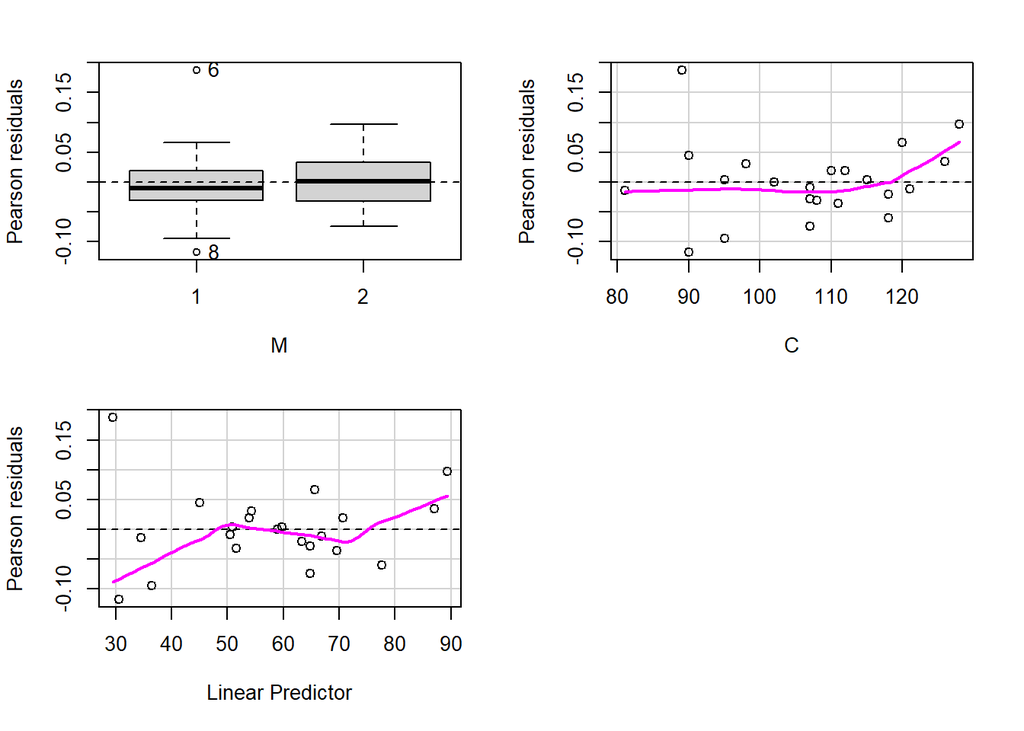

```
##   Test stat Pr(>|Test stat|)
## M
## C    0.0081           0.9282
```

```r
residualPlots(mvgg)
```

#### Predicció

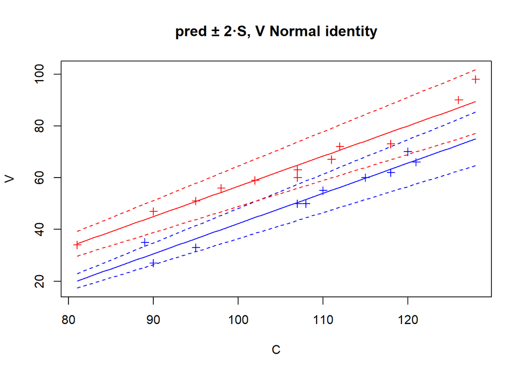

```r
CS <- min(dd$C):max(dd$C)

P1 <- predict(mvgg, data.frame(C=CS, M="1"), type = "response")        # Point estimates M=1
P2 <- predict(mvgg, data.frame(C=CS, M="2"), type = "response")        # Point estimates M=2

disp      <- summary(mvgg)$dispersion  # parametre de dispersio
var_func1 <- family(mvgg)$variance(P1) # funcio de variancia M=1
var_func2 <- family(mvgg)$variance(P2) # funcio de variancia M=2

IP1 <- cbind(P1 - 2 * sqrt(disp * var_func1),
             P1 + 2 * sqrt(disp * var_func1))
IP2 <- cbind(P2 - 2 * sqrt(disp * var_func2),
             P2 + 2 * sqrt(disp * var_func2))

# Punts pels 2 metodes
plot  (V ~ C, dd1, pch=3, col="blue", xlim = range(CS), ylim = range(c(IP1,IP2)),
       main="pred ± 2·S, V Normal identity")
points(V ~ C, dd2, pch=3, col="red")

# IP metode 1
lines(CS, P1,      col="blue")
lines(CS, IP1[,1], col="blue", lty=2)
lines(CS, IP1[,2], col="blue", lty=2)

# IP metode 2
lines(CS, P2,      col="red")
lines(CS, IP2[,1], col="red", lty=2)
lines(CS, IP2[,2], col="red", lty=2)
```

## Models amb *VV* com resposta

### Família normal amb link canònic (*identity*). Sense interacció

#### Model

- El Model sense interacció s’anomena **additiu** (*mvvg*)
- El model **nul** és aquell que no té cap variable explicativa (*mvvg0*)

```r
mvvg  <- glm(VV ~ M+C, family=gaussian, dd)
mvvg0 <- glm(VV ~ 1,   family=gaussian, dd)
```

Resum del model

```r
summary(mvvg)
```

```
##
## Call:
## glm(formula = VV ~ M + C, family = gaussian, data = dd)
##
## Coefficients:
##               Estimate Std. Error t value Pr(>|t|)
## (Intercept) -124.02485   10.08185 -12.302  1.7e-10 ***
## M2             5.24411    2.34295   2.238   0.0374 *
## C              1.62931    0.09257  17.601  3.2e-13 ***
## ---
## Signif. codes:  0 '***' 0.001 '**' 0.01 '*' 0.05 '.' 0.1 ' ' 1
##
## (Dispersion parameter for gaussian family taken to be 29.89085)
##
##     Null deviance: 9896.36  on 21  degrees of freedom
## Residual deviance:  567.93  on 19  degrees of freedom
## AIC: 141.95
##
## Number of Fisher Scoring iterations: 2
```

Veient la descriptiva la següent interpretació és errònia ja que s’ha de considerar la interacció:

- Per cada increment unitari del coeficient intelectual (*C*), la valoració *VV* s’incrementa **1.63 unitats**.
- El mètode pedagògic 2 (*M2*), incrementa la valoració *VV* **5.2 unitats**.

Resum gràfic del model (`emmip` del paquet `emmeans`). No es correspon amb la realitat.

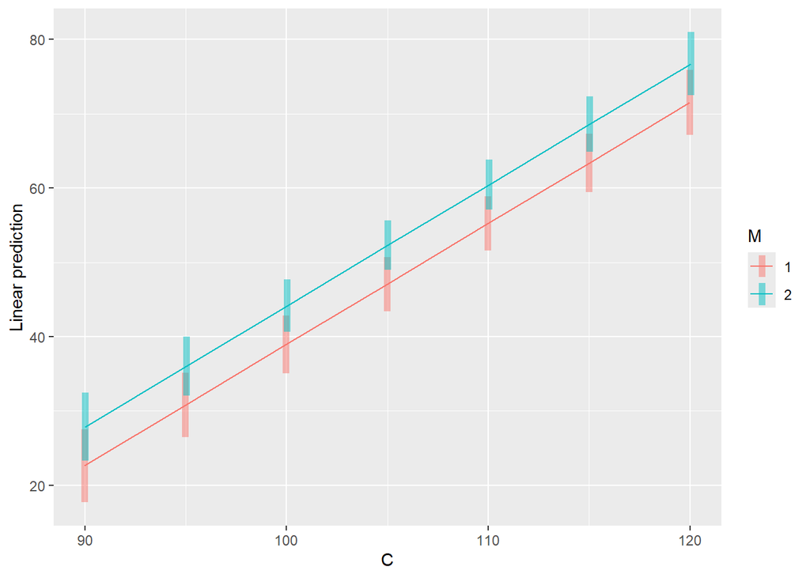

```r
emmip(mvvg, M~C, CIs=T, at=list(C=seq(90,120,5)))
```

**Test omnibus**. El test omnibus és aquell que compara el nostre model amb el model nul mitjançant un test de deviànces.

```r
anova(mvvg0, mvvg, test = "F")
```

```
## Analysis of Deviance Table
##
## Model 1: VV ~ 1
## Model 2: VV ~ M + C
##   Resid. Df Resid. Dev Df Deviance      F    Pr(>F)
## 1        21     9896.4
## 2        19      567.9  2   9328.4 156.04 1.617e-12 ***
## ---
## Signif. codes:  0 '***' 0.001 '**' 0.01 '*' 0.05 '.' 0.1 ' ' 1
```

#### Interpretació

Emprarem la funció `emmeans` per fer les estimacions als valors de C: 90, 105 i 120 (també podriem fer servir *predict*)

```r
emmeans(mvvg, ~M|C, at=list(C=c(90,105,120)))
```

```
## C =  90:
##  M emmean   SE df lower.CL upper.CL
##  1   22.6 2.36 19     17.7     27.5
##  2   27.9 2.18 19     23.3     32.4
##
## C = 105:
##  M emmean   SE df lower.CL upper.CL
##  1   47.1 1.74 19     43.4     50.7
##  2   52.3 1.58 19     49.0     55.6
##
## C = 120:
##  M emmean   SE df lower.CL upper.CL
##  1   71.5 2.09 19     67.1     75.9
##  2   76.7 2.03 19     72.5     81.0
##
## Confidence level used: 0.95
```

Emprarem la funció `emtrends` per fer les estimacions dels pendents de les dues rectes

```r
emtrends(mvvg, ~M, var="C")
```

```
##  M C.trend     SE df lower.CL upper.CL
##  1    1.63 0.0926 19     1.44     1.82
##  2    1.63 0.0926 19     1.44     1.82
##
## Confidence level used: 0.95
```

#### Validació

La **Linealitat** i la **Homoscedasticitat** es podrien millorar.

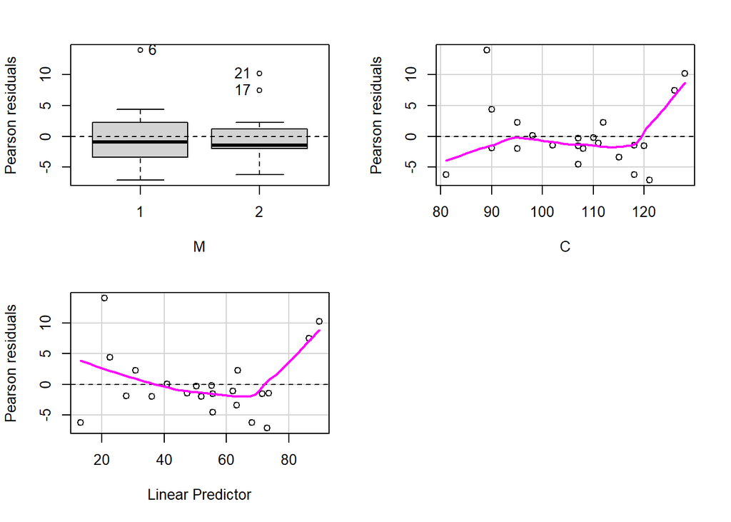

```
##   Test stat Pr(>|Test stat|)
## M
## C    51.805        6.131e-13 ***
## ---
## Signif. codes:  0 '***' 0.001 '**' 0.01 '*' 0.05 '.' 0.1 ' ' 1
```

```r
residualPlots(mvvg)
```

#### Prediccions

Banda predicció ± 2·S

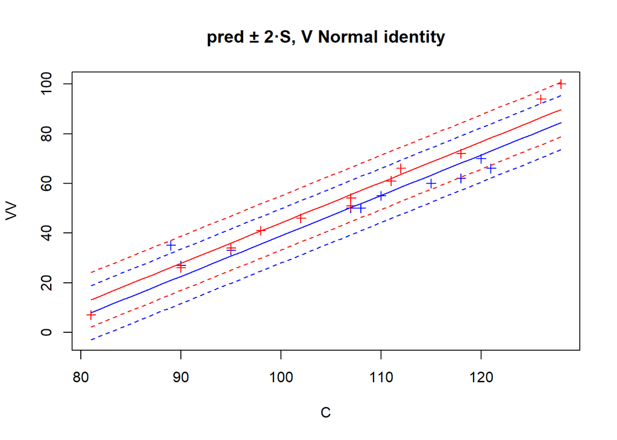

```r
CS <- min(dd$C):max(dd$C)

P1 <- predict(mvvg, data.frame(C=CS, M="1"), type = "response")        # Point estimates M=1
P2 <- predict(mvvg, data.frame(C=CS, M="2"), type = "response")        # Point estimates M=2

disp      <- summary(mvvg)$dispersion  # parametre de dispersio
var_func1 <- family(mvvg)$variance(P1) # funcio de variancia M=1
var_func2 <- family(mvvg)$variance(P2) # funcio de variancia M=2

IP1 <- cbind(P1 - 2 * sqrt(disp * var_func1),
             P1 + 2 * sqrt(disp * var_func1))
IP2 <- cbind(P2 - 2 * sqrt(disp * var_func2),
             P2 + 2 * sqrt(disp * var_func2))

# Punts pels 2 metodes
plot  (VV ~ C, dd1, pch=3, col="blue", xlim = range(CS), ylim = range(c(IP1,IP2)),
       main="pred ± 2·S, V Normal identity")
points(VV ~ C, dd2, pch=3, col="red")

# IP metode 1
lines(CS, P1,      col="blue")
lines(CS, IP1[,1], col="blue", lty=2)
lines(CS, IP1[,2], col="blue", lty=2)

# IP metode 2
lines(CS, P2,      col="red")
lines(CS, IP2[,1], col="red", lty=2)
lines(CS, IP2[,2], col="red", lty=2)
```

### Família normal amb link canònic (*identity*). Amb interacció

- El Model amb interacció s’anomena **factorial** (*mvvgl*)

```r
mvvgl  <- glm(VV ~ M*C, family=gaussian(link=identity),dd)
```

Resums dels models amb i sense interacció

```r
summary(mvvgl)
```

```
##
## Call:
## glm(formula = VV ~ M * C, family = gaussian(link = identity),
##     data = dd)
##
## Coefficients:
##              Estimate Std. Error t value Pr(>|t|)
## (Intercept) -77.49366    9.15403  -8.466 1.09e-07 ***
## M2          -69.20305   11.56736  -5.983 1.17e-05 ***
## C             1.19565    0.08483  14.095 3.64e-11 ***
## M2:C          0.69639    0.10750   6.478 4.30e-06 ***
## ---
## Signif. codes:  0 '***' 0.001 '**' 0.01 '*' 0.05 '.' 0.1 ' ' 1
##
## (Dispersion parameter for gaussian family taken to be 9.470607)
##
##     Null deviance: 9896.36  on 21  degrees of freedom
## Residual deviance:  170.47  on 18  degrees of freedom
## AIC: 117.48
##
## Number of Fisher Scoring iterations: 2
```

```r
summary(mvvg)
```

```
##
## Call:
## glm(formula = VV ~ M + C, family = gaussian, data = dd)
##
## Coefficients:
##               Estimate Std. Error t value Pr(>|t|)
## (Intercept) -124.02485   10.08185 -12.302  1.7e-10 ***
## M2             5.24411    2.34295   2.238   0.0374 *
## C              1.62931    0.09257  17.601  3.2e-13 ***
## ---
## Signif. codes:  0 '***' 0.001 '**' 0.01 '*' 0.05 '.' 0.1 ' ' 1
##
## (Dispersion parameter for gaussian family taken to be 29.89085)
##
##     Null deviance: 9896.36  on 21  degrees of freedom
## Residual deviance:  567.93  on 19  degrees of freedom
## AIC: 141.95
##
## Number of Fisher Scoring iterations: 2
```

Resums gràfics (emmip)

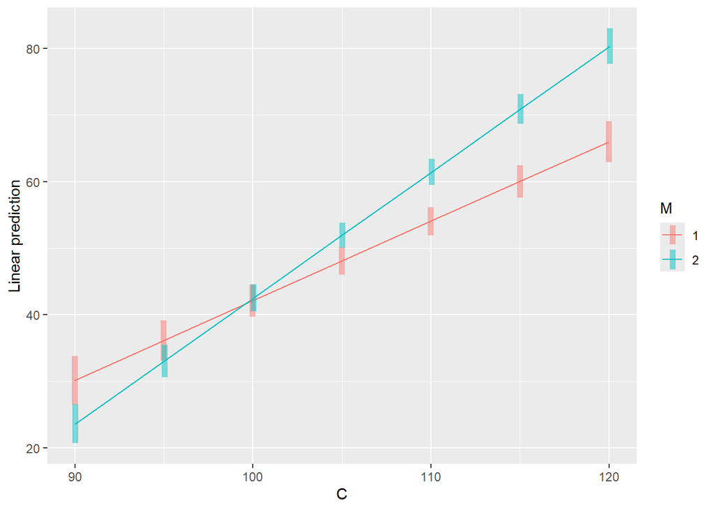

```r
emmip(mvvgl, M~C, CIs=T,at=list(C=seq(90,120,5)))
```

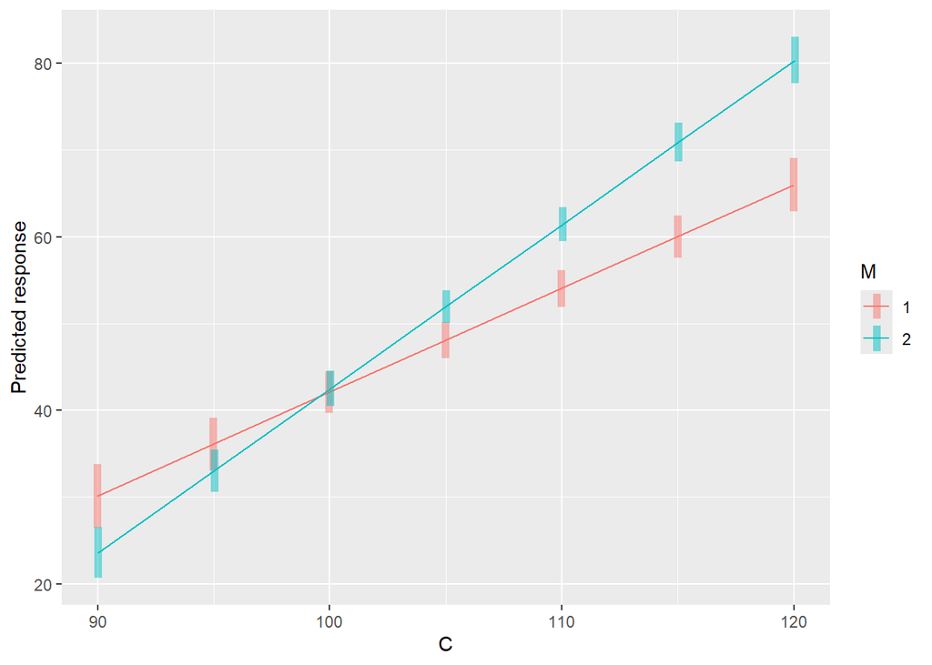

```r
emmip(mvvgl, M~C, CIs=T,at=list(C=seq(90,120,5)),type = "response")
```

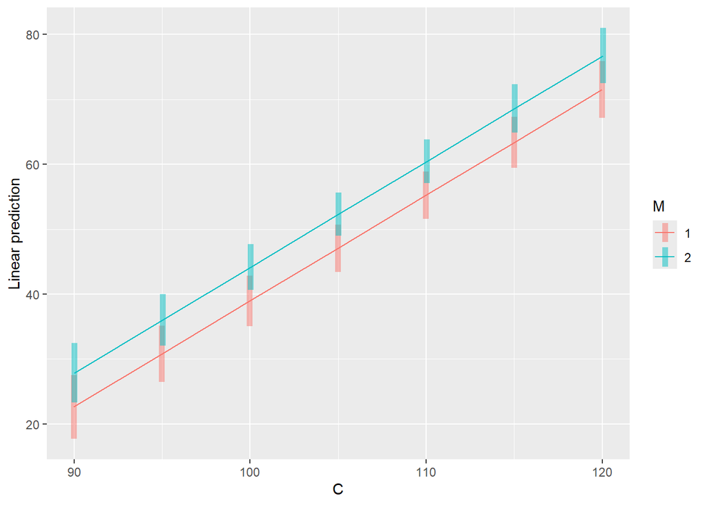

```r
emmip(mvvg,  M~C, CIs=T,at=list(C=seq(90,120,5)))
```

Comparem el model amb i sense interacció

```r
anova(mvvg, mvvgl,test = "F")
```

```
## Analysis of Deviance Table
##
## Model 1: VV ~ M + C
## Model 2: VV ~ M * C
##   Resid. Df Resid. Dev Df Deviance      F    Pr(>F)
## 1        19     567.93
## 2        18     170.47  1   397.46 41.967 4.296e-06 ***
## ---
## Signif. codes:  0 '***' 0.001 '**' 0.01 '*' 0.05 '.' 0.1 ' ' 1
```

#### Interpretació

Emprarem la funció `emmeans` per fer les estimacions als valors de C: 90, 105 i 120 (també podriem fer servir *predict*)

```r
emmeans(mvvgl,~M|C, at = list(C=c(90,105,120)))
```

```
## C =  90:
##  M emmean    SE df lower.CL upper.CL
##  1   30.1 1.761 18     26.4     33.8
##  2   23.6 1.393 18     20.7     26.5
##
## C = 105:
##  M emmean    SE df lower.CL upper.CL
##  1   48.0 0.993 18     46.0     50.1
##  2   52.0 0.892 18     50.1     53.8
##
## C = 120:
##  M emmean    SE df lower.CL upper.CL
##  1   66.0 1.452 18     62.9     69.0
##  2   80.3 1.270 18     77.7     83.0
##
## Confidence level used: 0.95
```

```r
emmeans(mvvg, ~M|C, at = list(C=c(90,105,120)))
```

```
## C =  90:
##  M emmean   SE df lower.CL upper.CL
##  1   22.6 2.36 19     17.7     27.5
##  2   27.9 2.18 19     23.3     32.4
##
## C = 105:
##  M emmean   SE df lower.CL upper.CL
##  1   47.1 1.74 19     43.4     50.7
##  2   52.3 1.58 19     49.0     55.6
##
## C = 120:
##  M emmean   SE df lower.CL upper.CL
##  1   71.5 2.09 19     67.1     75.9
##  2   76.7 2.03 19     72.5     81.0
##
## Confidence level used: 0.95
```

Emprarem la funció `emtrends` per fer les estimacions dels pendents de les dues rectes

```r
emtrends(mvvgl,~ M, var="C")
```

```
##  M C.trend     SE df lower.CL upper.CL
##  1    1.20 0.0848 18     1.02     1.37
##  2    1.89 0.0660 18     1.75     2.03
##
## Confidence level used: 0.95
```

```r
emtrends(mvvg, ~ M, var="C")
```

```
##  M C.trend     SE df lower.CL upper.CL
##  1    1.63 0.0926 19     1.44     1.82
##  2    1.63 0.0926 19     1.44     1.82
##
## Confidence level used: 0.95
```

#### Validació

La **Linealitat** i la **Homoscedasticitat** semblen comportar-se prou bé.

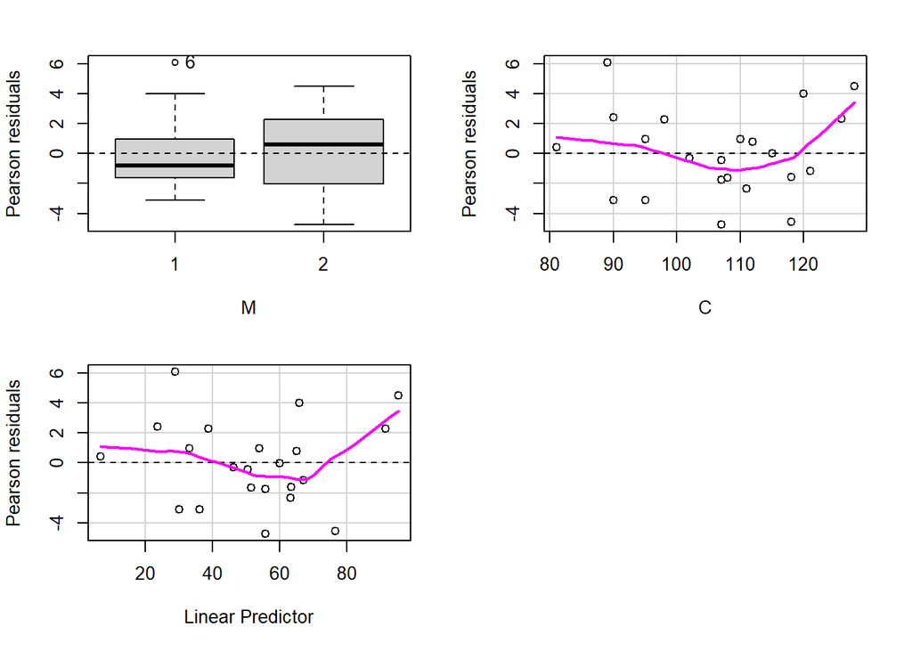

```
##   Test stat Pr(>|Test stat|)
## M
## C    33.425        7.405e-09 ***
## ---
## Signif. codes:  0 '***' 0.001 '**' 0.01 '*' 0.05 '.' 0.1 ' ' 1
```

```r
residualPlots(mvvgl)
```

**Valors estranys i influents**

El individu **6** és el que té més influència sobre el model (major distància de Cook) i també el pitjor explicat (residu més gran).

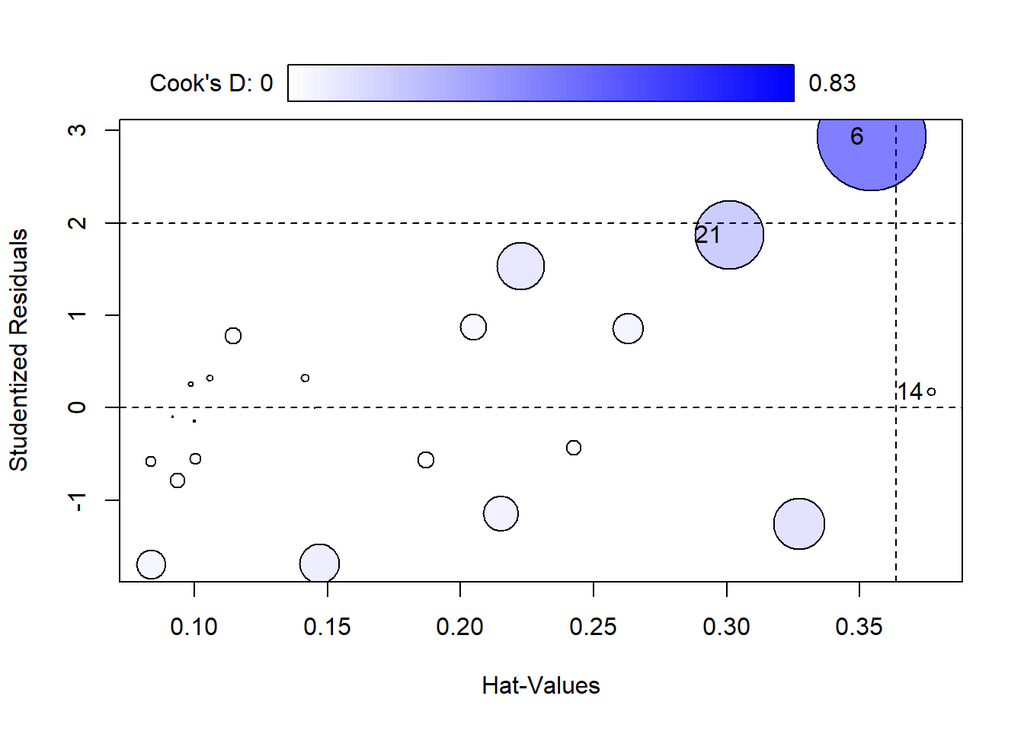

```
##      StudRes       Hat       CookD
## 6  2.9327748 0.3544563 0.830132298
## 14 0.1765227 0.3768366 0.004978753
## 21 1.8730933 0.3011087 0.331674084
```

```r
influencePlot(model = mvvgl)
```

#### Prediccions

Banda predicció ± 2·S

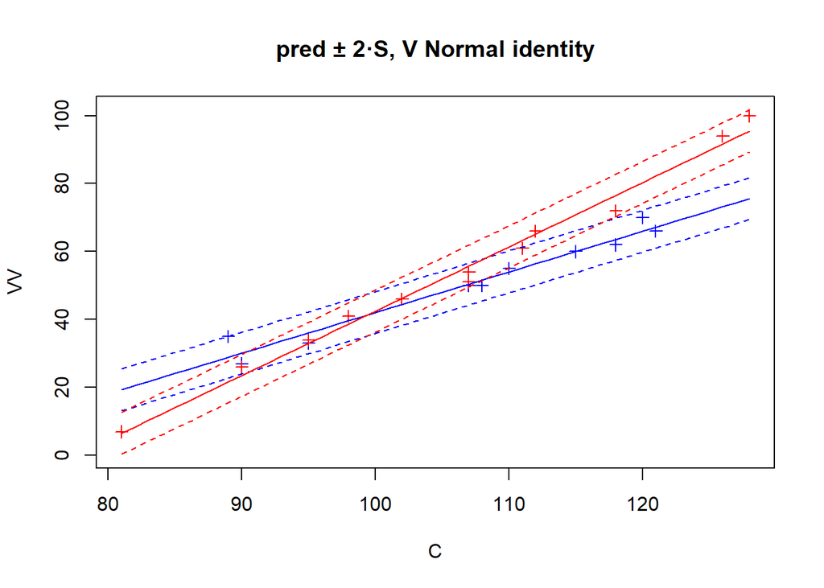

```r
CS <- min(dd$C):max(dd$C)

P1 <- predict(mvvgl, data.frame(C=CS, M="1"), type = "response")        # Point estimates M=1
P2 <- predict(mvvgl, data.frame(C=CS, M="2"), type = "response")        # Point estimates M=2

disp      <- summary(mvvgl)$dispersion  # parametre de dispersio
var_func1 <- family(mvvgl)$variance(P1) # funcio de variancia M=1
var_func2 <- family(mvvgl)$variance(P2) # funcio de variancia M=2

IP1 <- cbind(P1 - 2 * sqrt(disp * var_func1),
             P1 + 2 * sqrt(disp * var_func1))
IP2 <- cbind(P2 - 2 * sqrt(disp * var_func2),
             P2 + 2 * sqrt(disp * var_func2))

# Punts pels 2 metodes
plot  (VV ~ C, dd1, pch=3, col="blue", xlim = range(CS), ylim = range(c(IP1,IP2)),
       main="pred ± 2·S, V Normal identity")
points(VV ~ C, dd2, pch=3, col="red")

# IP metode 1
lines(CS, P1,      col="blue")
lines(CS, IP1[,1], col="blue", lty=2)
lines(CS, IP1[,2], col="blue", lty=2)

# IP metode 2
lines(CS, P2,      col="red")
lines(CS, IP2[,1], col="red", lty=2)
lines(CS, IP2[,2], col="red", lty=2)
```